### COVID-19 Understanding the spread and extent

#### Overview

The COVID19 is the biggest challenge to human existence in the past 100 years. In this project, we use the data made [publicly](https://data.humdata.org/dataset/novel-coronavirus-2019-ncov-cases) available to analyze the geographic spread and its impact. We analyse the data in terms of:

- Confirmed cases
- Fatal cases
- Recovered cases

#### A Global View

We start with a high level view of the spred and extent of the virus across the world. We can quickly see that the spread is global with China in East Asia, Iran in middle east followed by a bigger impact on Eurpoe and a much greater impact on the US.

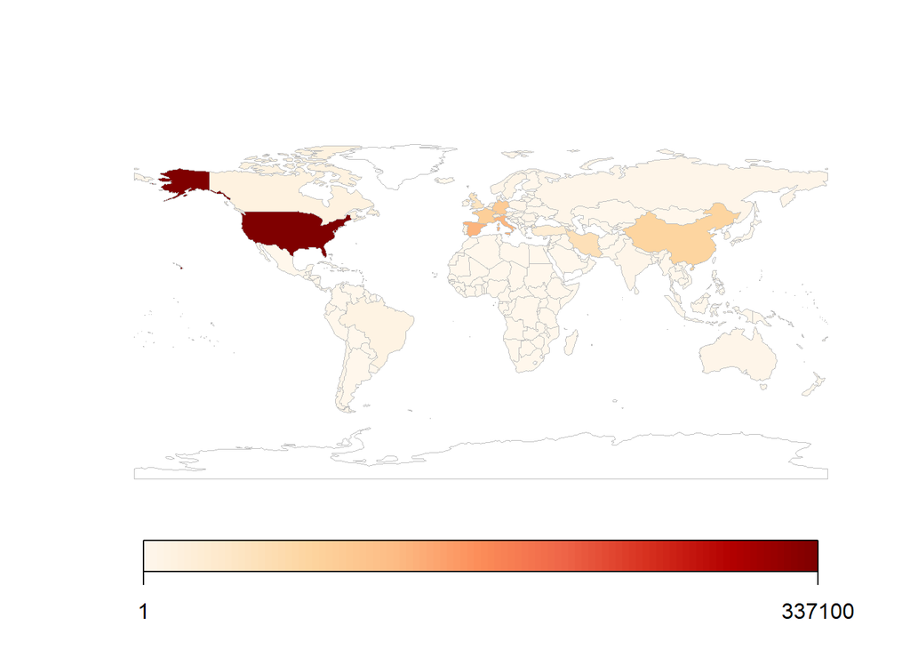

The following table provides a tabuar quantitative view of the above limited to the top 15 countries ordered on confirmed cases.

```
Country           Confirmed Cases   Death   Recovered
---------------  ----------------  ------  ----------
US                         337071    9619       17448
Spain                      131646   12641       38080
Italy                      128948   15887       21815
Germany                    100123    1584       28700
France                      93773    8093       16349
China                       82054    3316       77179
Iran                        58226    3603       19736
United Kingdom              48436    4943         229
Turkey                      27069     574        1042
Switzerland                 21100     715        6415
Belgium                     19691    1447        3751
Netherlands                 17953    1771         257
Austria                     12051     204        2998
Portugal                    11278     295          75
Brazil                      11130     486         127
```

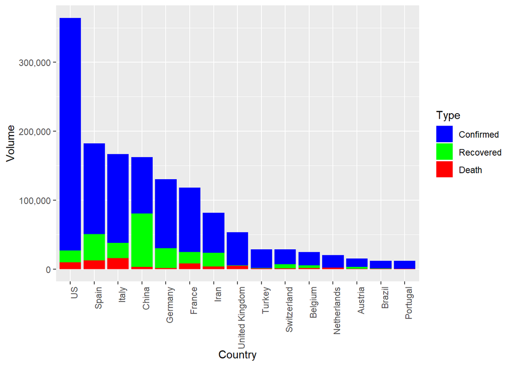